# HW3

## 2. Writing your success story

### a) Cleaning the Text and Word Cloud

```r
library(tm)

removeNumPunct <- function(x){
  gsub("[^[:alpha:][:space:]]*", "", x)
}

clean_corpus <- function(corpus){
  corpus <- tm_map(corpus, removePunctuation)
  corpus <- tm_map(corpus, content_transformer(tolower))
  corpus <- tm_map(corpus, removeWords, c(stopwords("en")))
  corpus <- tm_map(corpus, removeNumbers)
  corpus <- tm_map(corpus, content_transformer(removeNumPunct))
  corpus <- tm_map(corpus, stripWhitespace)
  return(corpus)
}

stemcompletion2 <- function(x, dictionary) {
   x <- unlist(strsplit(as.character(x), " "))
   x <- x[x != ""]
   x <- stemCompletion(x, dictionary=dictionary)
   x <- paste(x, sep="", collapse=" ")
   PlainTextDocument(stripWhitespace(x))
}
#subsetting most successful and least successful projects
kickstarter <- kickstarter %>% arrange(desc(pledged))
successful <- kickstarter[1:1000, ]
unsuccessful <- tail(kickstarter, n = 1000)
df <- rbind(successful, unsuccessful)

#Create function to get word frequency
get_word_frequency <- function(blah){
  # build a corpus, and specify the source to be character vectors
  blurb_corpus <- Corpus(VectorSource(blah))
  #apply the text cleaning function to the original corpus
  corpus_clean <- clean_corpus(blurb_corpus)
  #keep a copy of corpus to use later as a dictionary for stem completion
  corpus_clean_copy <- corpus_clean
  #stemming
  corpus_stem <- tm_map(corpus_clean, stemDocument)
  #stem completion
  corpus_comp <- lapply(corpus_stem, stemcompletion2, dictionary = corpus_clean_copy)
  #convert list into a corpus
  corpus_comp <- as.VCorpus(corpus_comp)

  tdm <- TermDocumentMatrix(corpus_comp)
  tdm_m <- as.matrix(tdm)
  word.freq <- sort(rowSums(tdm_m), decreasing = T)

  return(word.freq)
}
#get word frequency for successful and unsuccessful proejcts to be used in question 2-b.
positive_wf <- get_word_frequency(successful$blurb)
negative_wf <- get_word_frequency(unsuccessful$blurb)
```

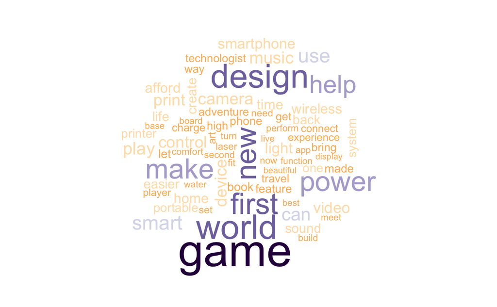

```r
set.seed(1234)

word.freq=positive_wf
purple_orange <- brewer.pal(10, "PuOr")
purple_orange <- purple_orange[-(1:2)]
dev.new(width = 1000, height = 1000, unit = "px")
wordcloud(words = names(word.freq), freq = word.freq, max.words = 70, colors = purple_orange, scale = c(4, 0.1))

knitr::include_graphics("000004.png")
```

For the wordcloud, I decided to use frequency of words, because use term frequency resulted in many words being dropped and not plotted. According to this wordcloud, it seems to be that the most frequent words for successful projects are: “game”, “design”, and “world”.

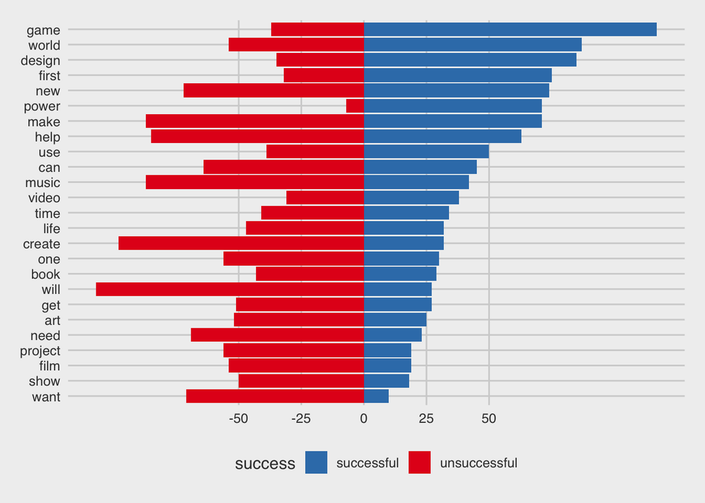

```r
### b) Success in words
#converting the word frequency which is a vector form to a data frame
pos_wf=data.frame(keyName=names(positive_wf), value=positive_wf, row.names=NULL)
neg_wf=data.frame(keyName=names(negative_wf), value=negative_wf, row.names=NULL)
neg_wf$value=neg_wf$value*-1

#inner join two data frames by the common words
pos_and_neg=merge(pos_wf, neg_wf,by='keyName',
     type = "inner") %>% arrange(desc(value.x-value.y))

#get the top 25 most frequent common words
pos_and_neg=pos_and_neg[1:25,]

#reshape the data frame from a wide to long form in order to plot the pyramid plot
merged_long<- reshape(data=pos_and_neg, idvar="keyName",
                         varying = c("value.x","value.y"),
                         v.name=c("freq"),
                         times=c("successful","unsuccessful"),
                         #new.row.names = 1:1000,
                        timevar='success',
                         direction="long")

#create a pyramid plot
ggplot(merged_long, aes(x = reorder(keyName, freq),
                  y = freq, fill = success)) +
  geom_bar(data = filter(merged_long, success == "successful"), stat = "identity") +
  geom_bar(data = filter(merged_long, success == "unsuccessful"), stat = "identity") +
  scale_fill_brewer(palette = "Set1", direction=-1) + coord_flip() +
  scale_y_continuous(breaks = seq(-50, 50, 25)) + ylab("") +
  theme_fivethirtyeight()
```

According to the pyramid plot above, the word “game” is the most frequent word for successful projects, whereas it appread relatively less in the desription for unsuccessful projects. Some of the most frequent words were “will” and “want”, which did not show up frequently in the description for successful projects. The plot above provides useful insights in terms of which words should be used to describe he project, in order to increase the chances of getting more funding.